# ESM206-Lab8

Anusha Sridhara

11/15/2021

## Read in the data

```r
homes <- read_csv(here("data","slo_homes.csv"))
```

A little bit of cleaning:

Make a subset called homes_sub that only contains observations (rows) where the city is: - san Luis Obispo - Arroyo Grande - Atascadero - Santa Maria-Orcutt

```r
homes_sub <- homes %>%
  filter(City %in% c("San Luis Obispo", "Arroyo Grande", "Atascadero", "Santa Maria-Orcutt"))
```

## Do a little exploring of our data

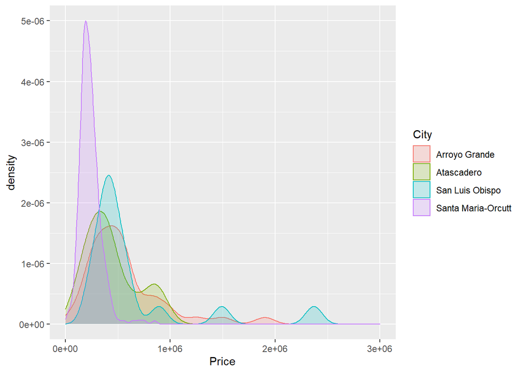

```r
ggplot(data = homes_sub, aes(x=Price))+
  geom_density(aes(color= City, fill=City), alpha = 0.2)+
  scale_x_continuous(limits =c(0, 3e6))
```

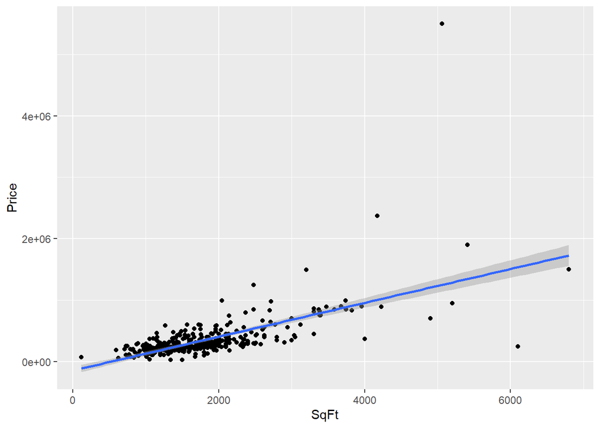

```r
ggplot(data = homes_sub, aes(x= SqFt, y= Price))+
  geom_point()+
  geom_smooth(method = lm)
```

## Model the relationship with home price as DV

```r
homes_lm1 <- lm(Price ~ City + Bedrooms + Bathrooms + SqFt + PricePerSqFt + Status, data = homes_sub)

# Make a subset that only contains the quantitative variables
homes_quant <- homes_sub %>%
  select(Price:PricePerSqFt)

homes_cor <- cor(homes_quant)
homes_cor
```

```
##                  Price    Bedrooms Bathrooms      SqFt PricePerSqFt
## Price        1.0000000  0.27035797 0.4867782 0.6372218   0.75236213
## Bedrooms     0.2703580  1.00000000 0.6429855 0.6195391  -0.04047523
## Bathrooms    0.4867782  0.64298545 1.0000000 0.7721538   0.11223286
## SqFt         0.6372218  0.61953907 0.7721538 1.0000000   0.17961762
## PricePerSqFt 0.7523621 -0.04047523 0.1122329 0.1796176   1.00000000
```

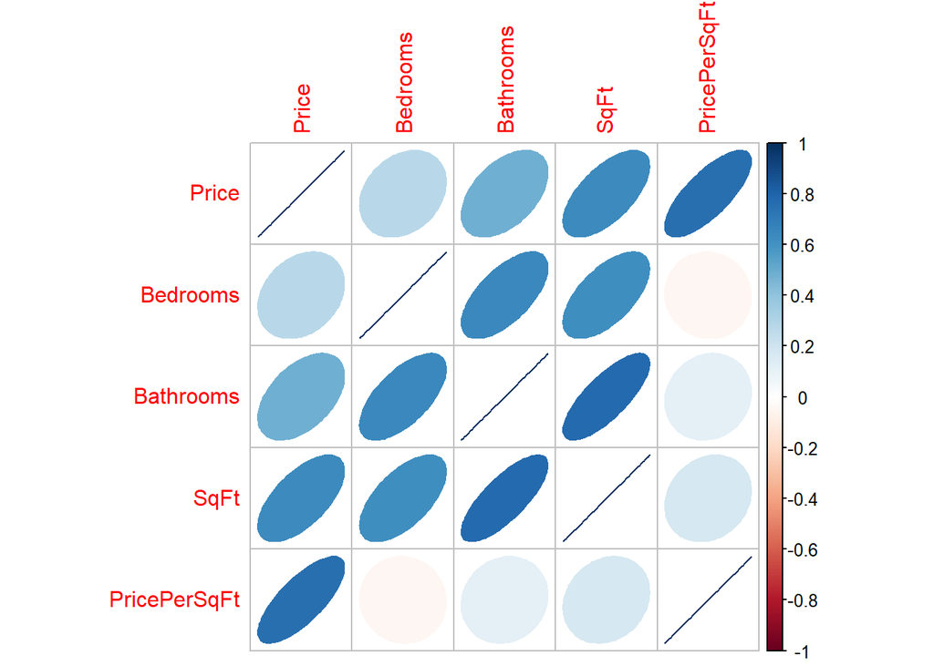

```r
corrplot(homes_cor, method = "ellipse")
```

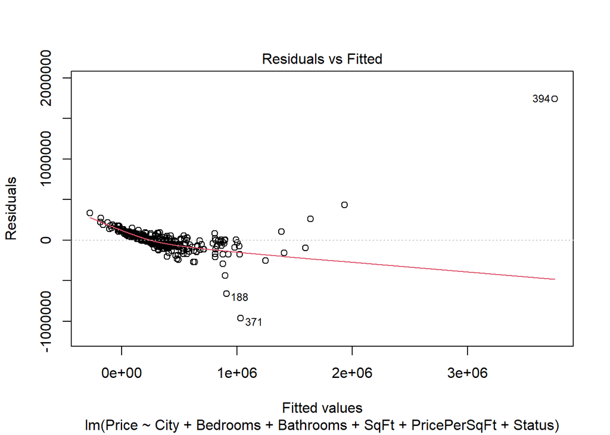

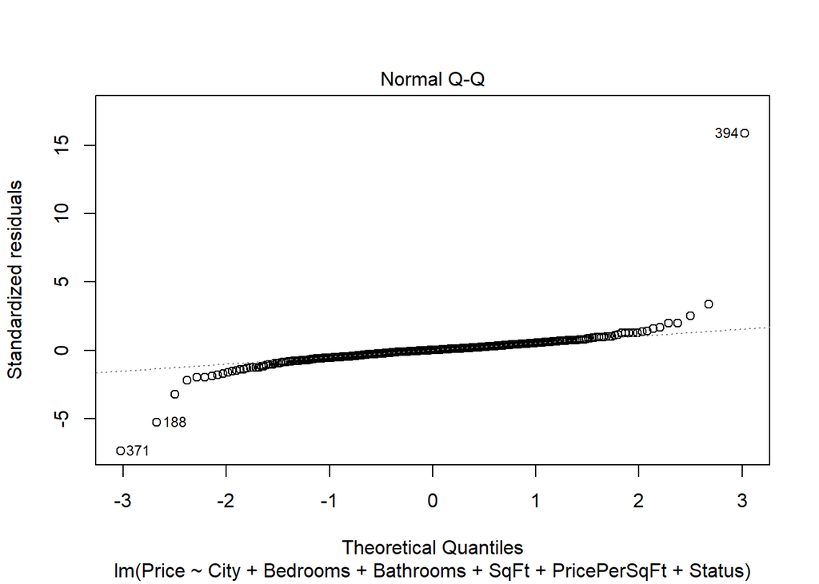

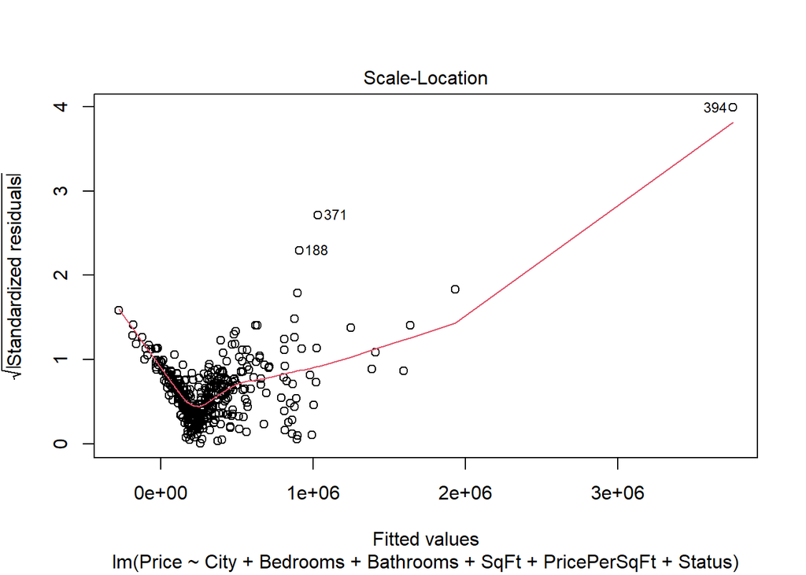

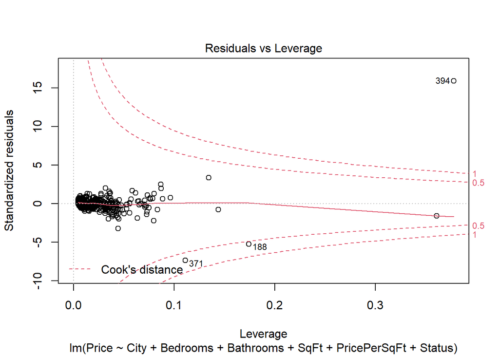

```r
# How would I explore diagnostic plots?
plot(homes_lm1)
```

Try another model (homes_lm2) where we simplify this a bit: - City - SqFt - Status

```r
homes_lm2 <- lm(Price ~ City + SqFt + Status, data = homes_sub)

# Or just call this in the console
homes_lm2
```

```
##
## Call:
## lm(formula = Price ~ City + SqFt + Status, data = homes_sub)
##
## Coefficients:
##            (Intercept)          CityAtascadero     CitySan Luis Obispo
##               106333.1               -202157.5                 34525.4
## CitySanta Maria-Orcutt                    SqFt           StatusRegular
##              -275841.3                   245.9                209998.9
##       StatusShort Sale
##                 2282.4
```

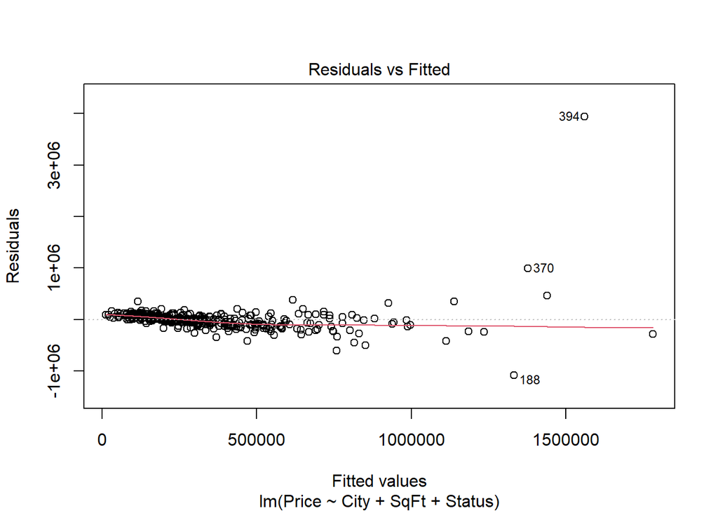

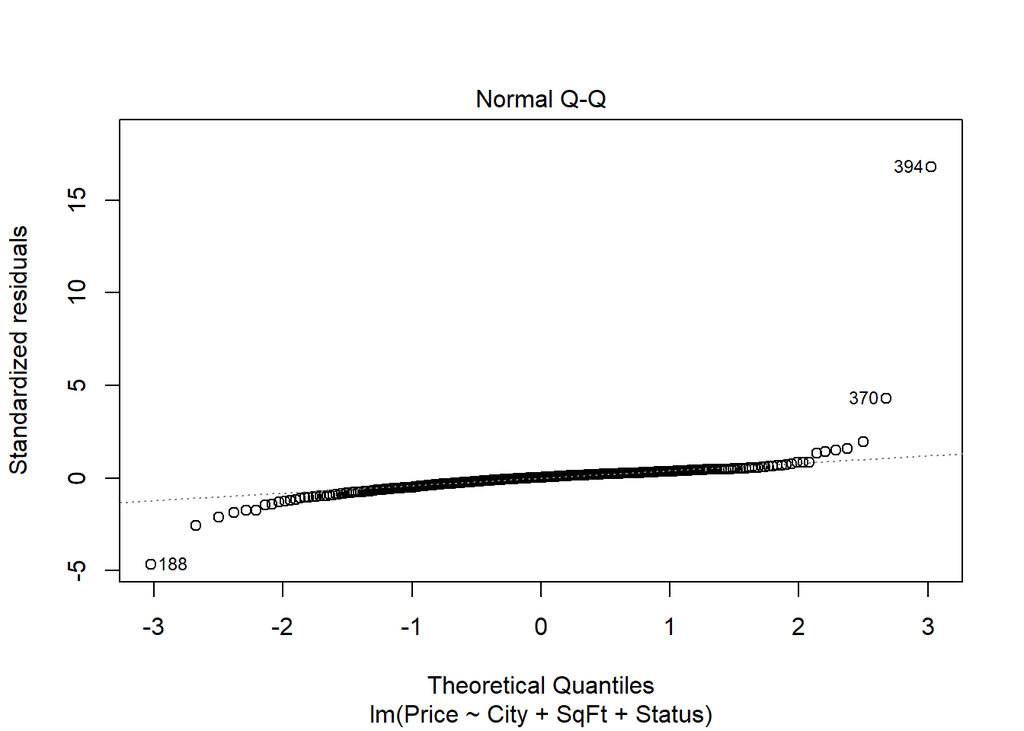

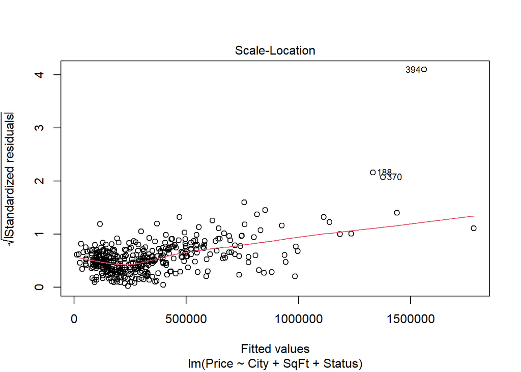

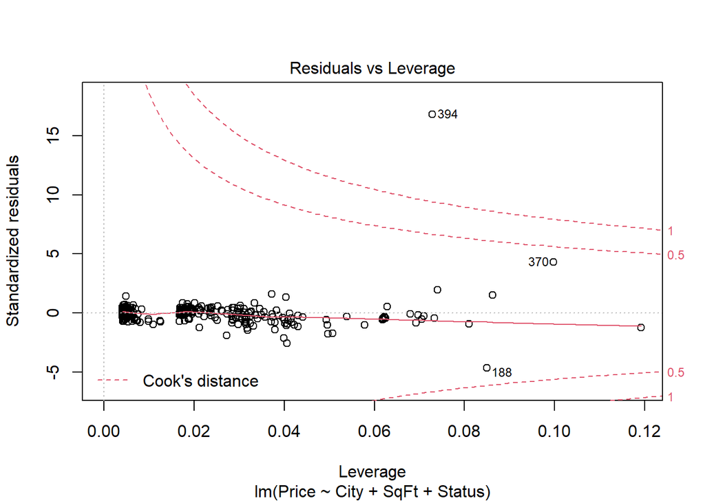

```r
# How would I explore diagnostic plots?
plot(homes_lm2)
```

53% of variance in home price is explained by variables in the model - city, sqft and status model fit and model complexity - AIC helps with the balance of the two.

Find the AIC value of each model:

```r
AIC(homes_lm1)
```

```
## [1] 10699.25
```

```r
AIC(homes_lm2)
```

```
## [1] 11148
```

```r
# lower aic values suggest better fit
```

Try another permutation of this model that you might think might make sense, check out & compare the model fit, outputs and AIC value

```r
homes_lm3 <- lm(Price ~ City + Bedrooms + SqFt + PricePerSqFt + Status, data = homes_sub)

homes_lm3
```

```
##
## Call:
## lm(formula = Price ~ City + Bedrooms + SqFt + PricePerSqFt +
##     Status, data = homes_sub)
##
## Coefficients:
##            (Intercept)          CityAtascadero     CitySan Luis Obispo
##              -623623.1                 -3212.1                -64263.3
## CitySanta Maria-Orcutt                Bedrooms                    SqFt
##               123976.1                -23124.3                   249.1
##           PricePerSqFt           StatusRegular        StatusShort Sale
##                 2967.7                -19622.5                -38262.4
```

```r
AIC(homes_lm3)
```

```
## [1] 10701.8
```

```r
homes_lm4 <- lm(Price ~ City + SqFt + Bedrooms + Status, data = homes_sub)

summary(homes_lm4)
```

```
##
## Call:
## lm(formula = Price ~ City + SqFt + Bedrooms + Status, data = homes_sub)
##
## Residuals:
##      Min       1Q   Median       3Q      Max
## -1157575   -59536     6015    66999  3872483
##
## Coefficients:
##                          Estimate Std. Error t value Pr(>|t|)
## (Intercept)             195411.31   64547.65   3.027  0.00263 **
## CityAtascadero         -192720.33   48713.65  -3.956 9.03e-05 ***
## CitySan Luis Obispo      30329.41   70175.70   0.432  0.66584
## CitySanta Maria-Orcutt -256745.21   43072.76  -5.961 5.57e-09 ***
## SqFt                       282.59      19.63  14.397  < 2e-16 ***
## Bedrooms                -51934.39   17631.90  -2.945  0.00342 **
## StatusRegular           208959.75   49164.06   4.250 2.67e-05 ***
## StatusShort Sale           372.99   32586.28   0.011  0.99087
## ---
## Signif. codes:  0 '***' 0.001 '**' 0.01 '*' 0.05 '.' 0.1 ' ' 1
##
## Residual standard error: 240800 on 395 degrees of freedom
## Multiple R-squared:  0.5439, Adjusted R-squared:  0.5358
## F-statistic:  67.3 on 7 and 395 DF,  p-value: < 2.2e-16
```

```r
AIC(homes_lm4)
```

```
## [1] 11141.24
```

Use ‘modelsummary’ to show model outputs side-by-side:

If you use modelsummary to return model outputs of multiple models, it wants you to feed it to it as a list

```r
modelsummary(list(homes_lm1, homes_lm2, homes_lm3))
```

|  | Model 1 | Model 2 | Model 3 |
| --- | --- | --- | --- |
| (Intercept) | -626690.877 | 106333.118 | -623623.057 |
|  | (47272.695) | (57574.568) | (47457.650) |
| CityAtascadero | -9068.194 | -202157.509 | -3212.076 |
|  | (29012.351) | (49077.007) | (29006.329) |
| CitySan Luis Obispo | -76863.041 | 34525.409 | -64263.271 |
|  | (41030.471) | (70837.962) | (40772.853) |
| CitySanta Maria-Orcutt | 120160.701 | -275841.282 | 123976.084 |
|  | (28338.220) | (42992.765) | (28404.675) |
| Bedrooms | -30792.773 |  | -23124.309 |
|  | (10841.581) |  | (10260.820) |
| Bathrooms | 27998.673 |  |  |
|  | (13251.722) |  |  |
| SqFt | 230.726 | 245.934 | 249.056 |
|  | (14.308) | (15.325) | (11.427) |
| PricePerSqFt | 2962.850 |  | 2967.681 |
|  | (105.537) |  | (105.975) |
| StatusRegular | -19792.272 | 209998.857 | -19622.496 |
|  | (29484.606) | (49636.975) | (29613.828) |
| StatusShort Sale | -41575.706 | 2282.420 | -38262.412 |
|  | (18900.819) | (32894.066) | (18918.273) |
| Num.Obs. | 403 | 403 | 403 |
| R2 | 0.849 | 0.534 | 0.847 |
| R2 Adj. | 0.846 | 0.527 | 0.844 |
| AIC | 10699.2 | 11148.0 | 10701.8 |
| BIC | 10743.2 | 11180.0 | 10741.8 |
| Log.Lik. | -5338.624 | -5566.000 | -5340.900 |
| F | 245.896 | 75.603 | 273.669 |